# Stroke

2023-10-11

```r
library(devtools)
devtools::install_github("physicsland/ezids")
library(ezids)
```

Read the data:

```r
stroke = read.csv("full_data.csv")
head(stroke)
```

```
##   gender age hypertension heart_disease ever_married     work_type
## 1   Male  67            0             1          Yes       Private
## 2   Male  80            0             1          Yes       Private
## 3 Female  49            0             0          Yes       Private
## 4 Female  79            1             0          Yes Self-employed
## 5   Male  81            0             0          Yes       Private
## 6   Male  74            1             1          Yes       Private
##   Residence_type avg_glucose_level  bmi  smoking_status stroke
## 1          Urban            228.69 36.6 formerly smoked      1
## 2          Rural            105.92 32.5    never smoked      1
## 3          Urban            171.23 34.4          smokes      1
## 4          Rural            174.12 24.0    never smoked      1
## 5          Urban            186.21 29.0 formerly smoked      1
## 6          Rural             70.09 27.4    never smoked      1
```

```r
tail(stroke)
```

```
##      gender age hypertension heart_disease ever_married work_type
## 4976   Male  31            0             0           No   Private
## 4977   Male  41            0             0           No   Private
## 4978   Male  40            0             0          Yes   Private
## 4979 Female  45            1             0          Yes  Govt_job
## 4980   Male  40            0             0          Yes   Private
## 4981 Female  80            1             0          Yes   Private
##      Residence_type avg_glucose_level  bmi  smoking_status stroke
## 4976          Urban            215.07 32.7          smokes      0
## 4977          Rural             70.15 29.8 formerly smoked      0
## 4978          Urban            191.15 31.1          smokes      0
## 4979          Rural             95.02 31.8          smokes      0
## 4980          Rural             83.94 30.0          smokes      0
## 4981          Urban             83.75 29.1    never smoked      0
```

**Summary of the Stroke Data**

```r
summary_stroke <- xkablesummary(stroke[1, ][c("age","hypertension","heart_disease","stroke")])
summary_stroke
```

Table: Statistics summary.

[output not shown]

**Checking for missing values in the data**

```r
missing_values <- is.na(stroke)
summary(missing_values)
```

```
##    gender           age          hypertension    heart_disease
##  Mode :logical   Mode :logical   Mode :logical   Mode :logical
##  FALSE:4981      FALSE:4981      FALSE:4981      FALSE:4981
##  ever_married    work_type       Residence_type  avg_glucose_level
##  Mode :logical   Mode :logical   Mode :logical   Mode :logical
##  FALSE:4981      FALSE:4981      FALSE:4981      FALSE:4981
##     bmi          smoking_status    stroke
##  Mode :logical   Mode :logical   Mode :logical
##  FALSE:4981      FALSE:4981      FALSE:4981
```

**Changing the work_type children to unemployed**

```r
stroke$work_type <- ifelse(stroke$work_type == "children", "unemployed", stroke$work_type)
print(head(stroke))
```

```
##   gender age hypertension heart_disease ever_married     work_type
## 1   Male  67            0             1          Yes       Private
## 2   Male  80            0             1          Yes       Private
## 3 Female  49            0             0          Yes       Private
## 4 Female  79            1             0          Yes Self-employed
## 5   Male  81            0             0          Yes       Private
## 6   Male  74            1             1          Yes       Private
##   Residence_type avg_glucose_level  bmi  smoking_status stroke
## 1          Urban            228.69 36.6 formerly smoked      1
## 2          Rural            105.92 32.5    never smoked      1
## 3          Urban            171.23 34.4          smokes      1
## 4          Rural            174.12 24.0    never smoked      1
## 5          Urban            186.21 29.0 formerly smoked      1
## 6          Rural             70.09 27.4    never smoked      1
```

**Changing the categorical variable to numeric**

```r
#Changing gender to numerical
stroke$gender <- as.numeric(factor(stroke$gender))

#Changing work type to numerical
stroke$work_type <- as.numeric(factor(stroke$work_type))

#Changing the location to numerical
stroke$Residence_type <- as.numeric(factor(stroke$Residence_type))

#Changing the marriage status to numerical
stroke$ever_married <- as.numeric(factor(stroke$ever_married))

#Changing the smoking status to numerical
stroke$smoking_status <- as.numeric(factor(stroke$smoking_status))

final <- stroke
head(final)
```

```
##   gender age hypertension heart_disease ever_married work_type Residence_type
## 1      2  67            0             1            2         2              2
## 2      2  80            0             1            2         2              1
## 3      1  49            0             0            2         2              2
## 4      1  79            1             0            2         3              1
## 5      2  81            0             0            2         2              2
## 6      2  74            1             1            2         2              1
##   avg_glucose_level  bmi smoking_status stroke
## 1            228.69 36.6              1      1
## 2            105.92 32.5              2      1
## 3            171.23 34.4              3      1
## 4            174.12 24.0              2      1
## 5            186.21 29.0              1      1
## 6             70.09 27.4              2      1
```

```r
tail(final)
```

```
##      gender age hypertension heart_disease ever_married work_type
## 4976      2  31            0             0            1         2
## 4977      2  41            0             0            1         2
## 4978      2  40            0             0            2         2
## 4979      1  45            1             0            2         1
## 4980      2  40            0             0            2         2
## 4981      1  80            1             0            2         2
##      Residence_type avg_glucose_level  bmi smoking_status stroke
## 4976              2            215.07 32.7              3      0
## 4977              1             70.15 29.8              1      0
## 4978              2            191.15 31.1              3      0
## 4979              1             95.02 31.8              3      0
## 4980              1             83.94 30.0              3      0
## 4981              2             83.75 29.1              2      0
```

**Age Categories**

```r
age_breaks <- c(0, 10, 18, 60, Inf)
age_labels <- c("Children", "School", "Adult", "Senior Citizen")

# Create a new column with age categories
stroke$Category <- cut(stroke$age, breaks = age_breaks, labels = age_labels)

# Print the dataset
print(head(stroke))
```

```
##   gender age hypertension heart_disease ever_married work_type Residence_type
## 1      2  67            0             1            2         2              2
## 2      2  80            0             1            2         2              1
## 3      1  49            0             0            2         2              2
## 4      1  79            1             0            2         3              1
## 5      2  81            0             0            2         2              2
## 6      2  74            1             1            2         2              1
##   avg_glucose_level  bmi smoking_status stroke       Category
## 1            228.69 36.6              1      1 Senior Citizen
## 2            105.92 32.5              2      1 Senior Citizen
## 3            171.23 34.4              3      1          Adult
## 4            174.12 24.0              2      1 Senior Citizen
## 5            186.21 29.0              1      1 Senior Citizen
## 6             70.09 27.4              2      1 Senior Citizen
```

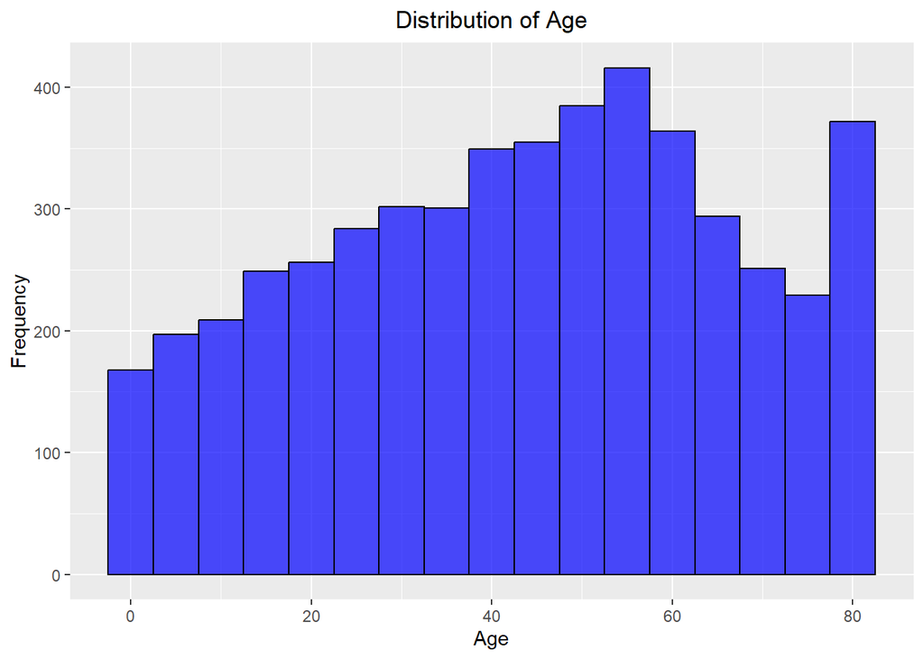

```r
library(ggplot2)
ggplot(stroke, aes(x = age)) +
  geom_histogram(binwidth = 5, fill = "blue", color = "black", alpha = 0.7) +
  ggtitle("Use theme(plot.title = element_text(hjust = 0.5)) to center") +
  theme(plot.title = element_text(hjust = 0.5)) +
  labs(title = "Distribution of Age",
       x = "Age",
       y = "Frequency")
```

**The effect of average glucose level in stroke**

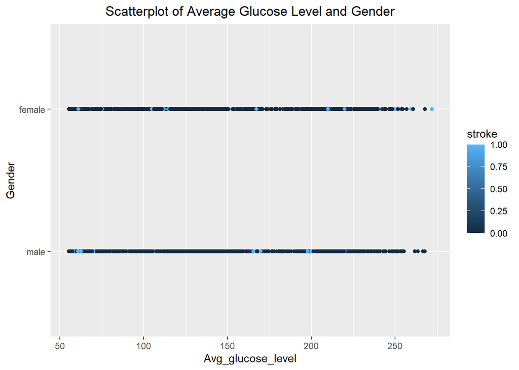

```r
library(ggplot2)
stroke$gender_label <- factor(ifelse(stroke$gender == 1, "male", "female"), levels = c("male", "female"))
ggplot(stroke, aes(y = gender_label, x = avg_glucose_level, color = stroke)) +
  geom_point() +
  ggtitle("Use theme(plot.title = element_text(hjust = 0.5)) to center") +
  theme(plot.title = element_text(hjust = 0.5)) +
  labs(title = "Scatterplot of Average Glucose Level and Gender",y = "Gender", x = "Avg_glucose_level")
```

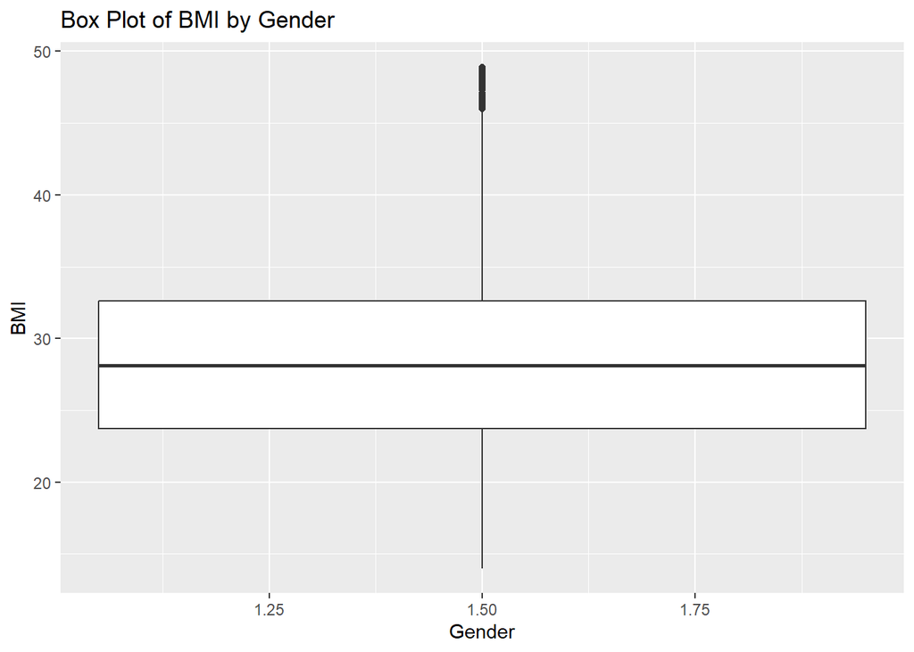

```r
library(ggplot2)
ggplot(stroke, aes(x = gender, y = bmi, fill = gender)) +
  geom_boxplot() +
  labs(
    title = "Box Plot of BMI by Gender",
    x = "Gender",
    y = "BMI"
  )
```

Null Hypothesis(H0): Age and stroke variables are independent.

Alternative Hypothesis(Ha): Age and stroke are not independent.

```r
Contingency_Table_Age <- table(stroke$Category , stroke$stroke)
Chi_Square_Test_Age_BS <- chisq.test(Contingency_Table_Age)
print(Chi_Square_Test_Age_BS$p.value)
```

```
## [1] 7.506175e-62
```

The p-value for this test is <0.05 (Standard Significane level), therefore we reject Null Hypothesis. Hence we can conclude that Age and stroke are not independent. Age group significantly matters in chances of having a brain stroke.

**Which category in age has highest number of Brain Strokes**

```r
print(Contingency_Table_Age)
```

```
##
##                     0    1
##   Children        492    1
##   School          386    1
##   Adult          2738   69
##   Senior Citizen 1117  177
```

```r
brain_stroke_yes <- subset(stroke,stroke == 1)
brain_stroke_no <- subset(stroke,stroke == 0)
```

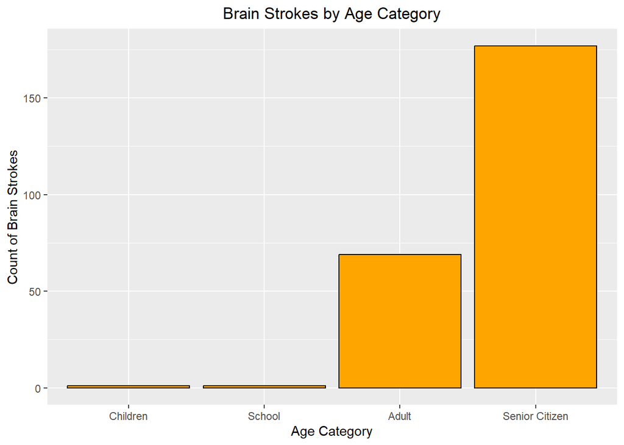

```r
ggplot(data = brain_stroke_yes, aes(x = `Category`, fill = `Category`)) +
  geom_bar(position = "stack",col="black", fill="Orange") +
  labs(title = "Brain Strokes by Age Category",
       x = "Age Category",
       y = "Count of Brain Strokes") +
  theme(plot.title = element_text(hjust = 0.5))
```

```r
library(dplyr)
```

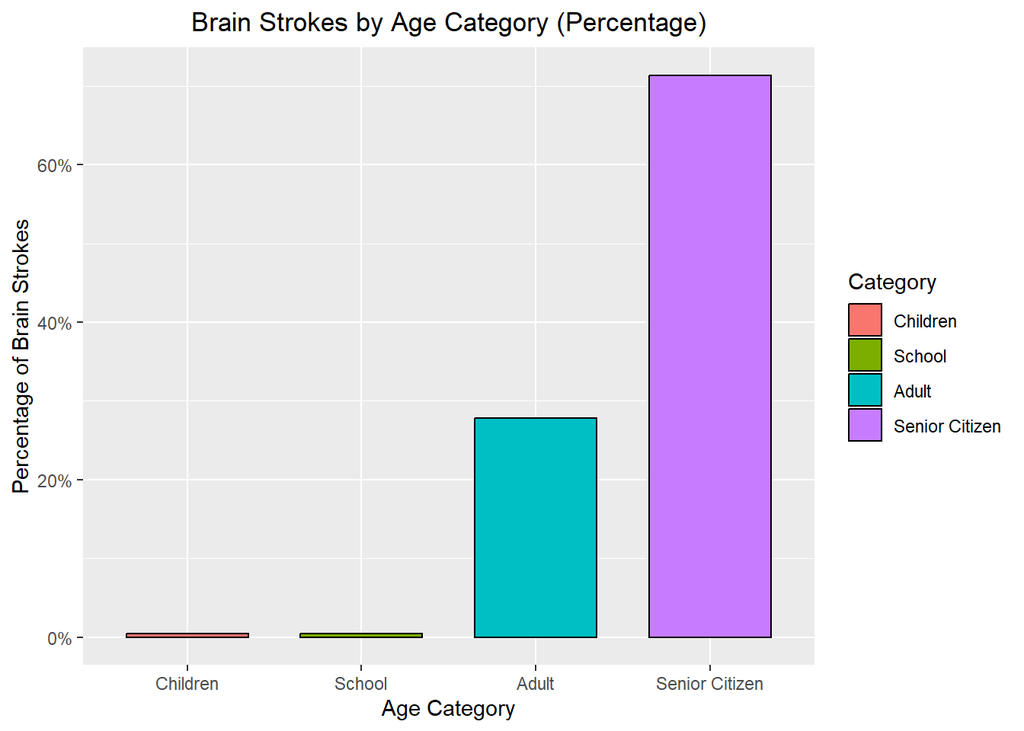

```r
# Calculate the total number of cases
total_cases <- nrow(brain_stroke_yes)

# Calculate the percentage of brain strokes for each age category
brain_stroke_yes_percentage <- brain_stroke_yes %>%
  group_by(Category) %>%
  summarise(Percentage = (n() / total_cases) * 100)

# Create the bar plot with percentages
ggplot(data = brain_stroke_yes_percentage, aes(x = `Category`, y = Percentage, fill = `Category`)) +
  geom_bar(stat = "identity", col = "black", width = 0.7, position = "stack") +
  labs(title = "Brain Strokes by Age Category (Percentage)",
       x = "Age Category",
       y = "Percentage of Brain Strokes") +
  scale_y_continuous(labels = scales::percent_format(scale = 1)) +  # Format y-axis as percentage
  theme(plot.title = element_text(hjust = 0.5))
```

The “Senior Citizen” age group exhibits the highest likelihood of experiencing a brain stroke, accounting for nearly 70% of cases

Null Hypothesis(H0): Worktype and stroke variables are independent.

Alternative Hypothesis(Ha): Worktype and stroke are not independent.

```r
Contingency_Table_worktype <- table(stroke$work_type , stroke$stroke)
Chi_Square_Test_worktype_BS <- chisq.test(Contingency_Table_worktype)
print(Chi_Square_Test_worktype_BS$p.value)
```

```
## [1] 2.312446e-10
```

The p-value for this test is <0.05 (Standard Significane level), therefore we reject Null Hypothesis. Hence we can conclude that worktype and stroke are not independent. Worktype significantly matters in chances of having a brain stroke.

**Which category in worktype has highest number of Brain Strokes***

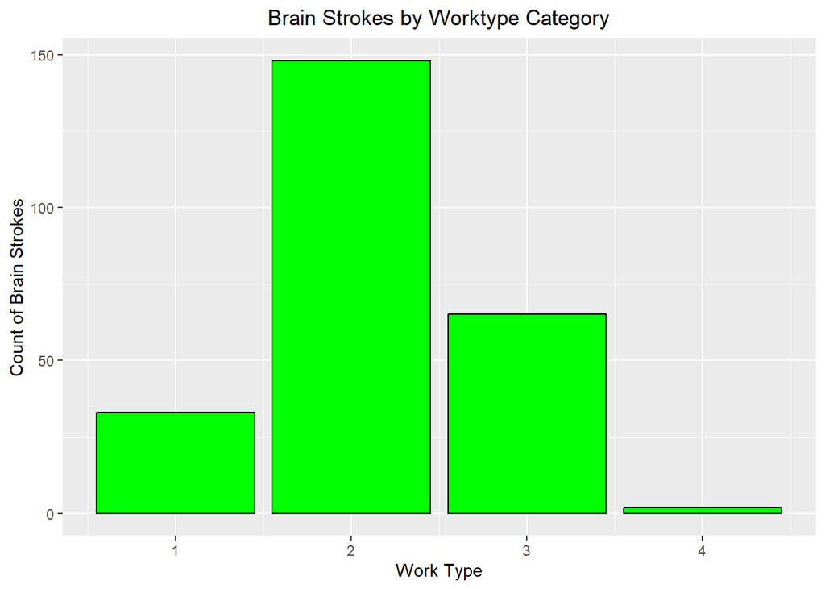

```r
ggplot(data = brain_stroke_yes, aes(x = `work_type`, fill = `work_type`)) +
  geom_bar(position = "stack",col="black", fill="Green",show.legend = TRUE) +
  labs(title = "Brain Strokes by Worktype Category",
       x = "Work Type",
       y = "Count of Brain Strokes") +
  scale_fill_manual(values = c("1" = "blue", "2" = "green", "3" = "red", "4" = "purple"),
                    labels = c("Government Job", "Private", "Self Employed", "Children")) +
  theme(plot.title = element_text(hjust = 0.5))
```

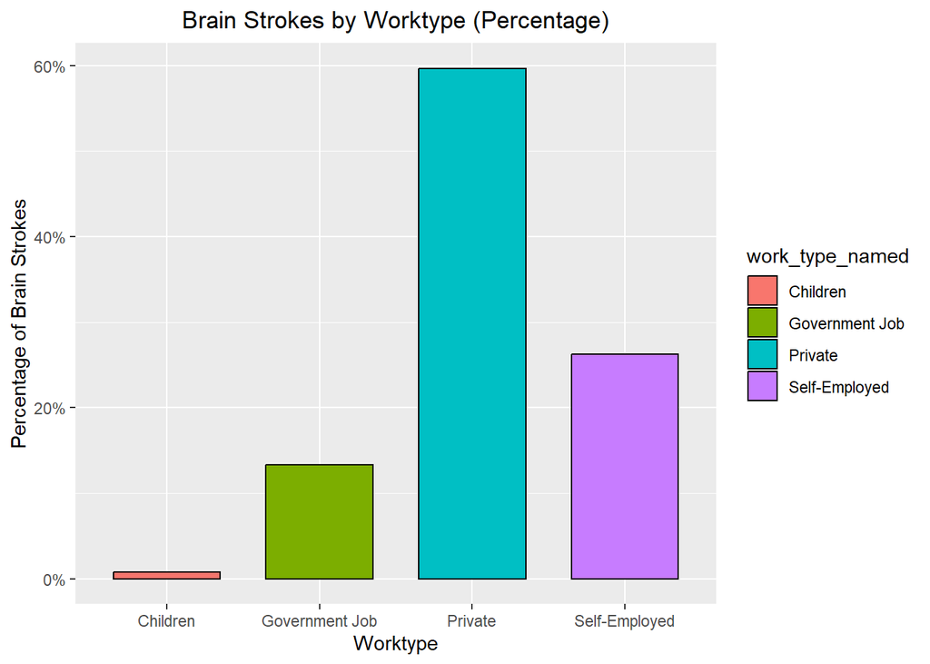

```r
brain_stroke_yes <- brain_stroke_yes %>%
  mutate(work_type_named = case_when(
    work_type == 1 ~ "Government Job",
    work_type == 2 ~ "Private",
    work_type == 3 ~ "Self-Employed",
    work_type == 4 ~ "Children"
  ))


# Calculate the percentage of brain strokes for each age category
brain_stroke_yes_percentage <- brain_stroke_yes %>%
  group_by(work_type_named) %>%
  summarise(Percentage = (n() / total_cases) * 100)

# Create the bar plot with percentages
ggplot(data = brain_stroke_yes_percentage, aes(x = `work_type_named`, y = Percentage, fill = `work_type_named`)) +
  geom_bar(stat = "identity", col = "black", width = 0.7, position = "stack") +
  labs(title = "Brain Strokes by Worktype (Percentage)",
       x = "Worktype",
       y = "Percentage of Brain Strokes") +
  scale_y_continuous(labels = scales::percent_format(scale = 1)) +  # Format y-axis as percentage
  theme(plot.title = element_text(hjust = 0.5))
```

The highest number of Brain strokes is for the Private working people.

**Does brain stroke depend on gender type?**

Null Hypothesis(H0): Gender and stroke variables are independent.

Alternative Hypothesis(Ha): Gender and stroke are not independent.

```r
Contingency_Table_Gender <- table(stroke$gender , stroke$stroke)
Chi_Square_Test_Gender_BS <- chisq.test(Contingency_Table_Gender)
print(Chi_Square_Test_Gender_BS$p.value)
```

```
## [1] 0.5755279
```

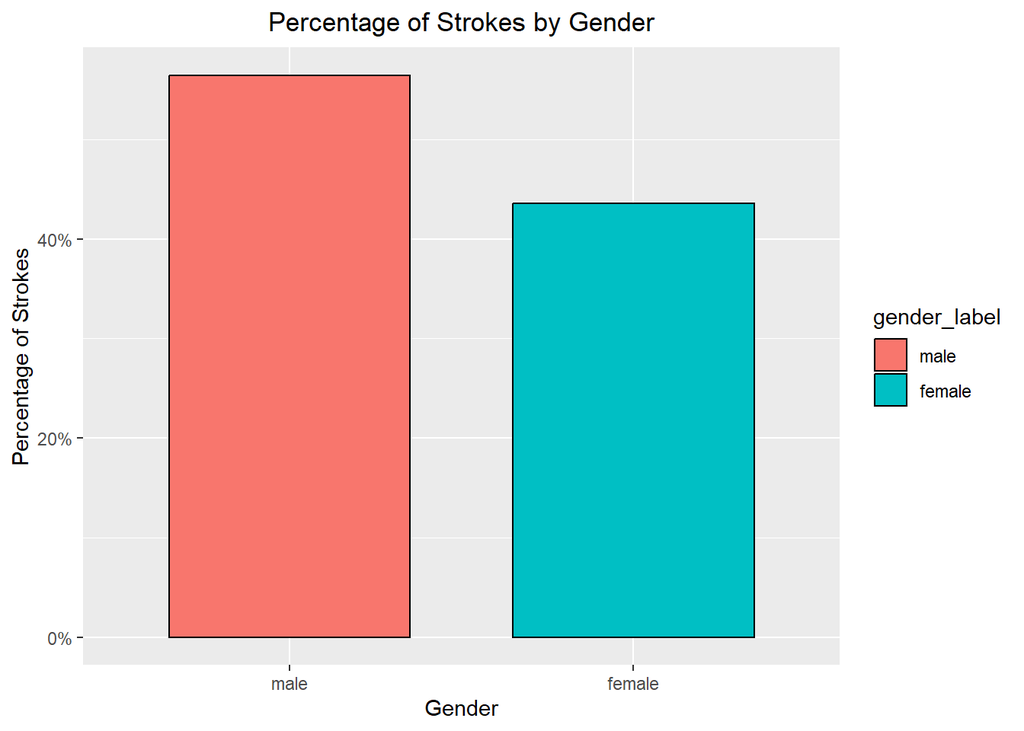

```r
# Calculate the percentage of brain strokes for each gender category
brain_stroke_yes_percentage <- brain_stroke_yes %>%
  group_by(gender_label) %>%
  summarise(Percentage = (n() / total_cases) * 100)

# Create the bar plot with percentages on the y-axis
ggplot(data = brain_stroke_yes_percentage, aes(x = gender_label, y = Percentage, fill = gender_label)) +
  geom_bar(stat = "identity", col = "black", width = 0.7, position = "stack") +
  labs(title = "Percentage of Strokes by Gender",
       x = "Gender",
       y = "Percentage of Strokes") +
  scale_y_continuous(labels = scales::percent_format(scale = 1)) +  # Format y-axis as percentage
  theme(plot.title = element_text(hjust = 0.5))
```

p-value is greater than 0.05 (Standard Significance level) and therefore we accept Null Hypothesis and so we can conclude that brain stroke doesn’t depend on gender type.

**Does brain stroke depend on Location type?**

Null Hypothesis(H0): Location and stroke variables are independent.

Alternative Hypothesis(Ha): Location and stroke are not independent.

```r
Contingency_Table_Location <- table(stroke$Residence_type , stroke$stroke)
Chi_Square_Test_Location_BS <- chisq.test(Contingency_Table_Location)
print(Chi_Square_Test_Location_BS$p.value)
```

```
## [1] 0.271793
```

p-value is greater than 0.05 (Standard Significance level) and therefore we accept Null Hypothesis and so we can conclude that brain stroke doesn’t depend on Location of residence.

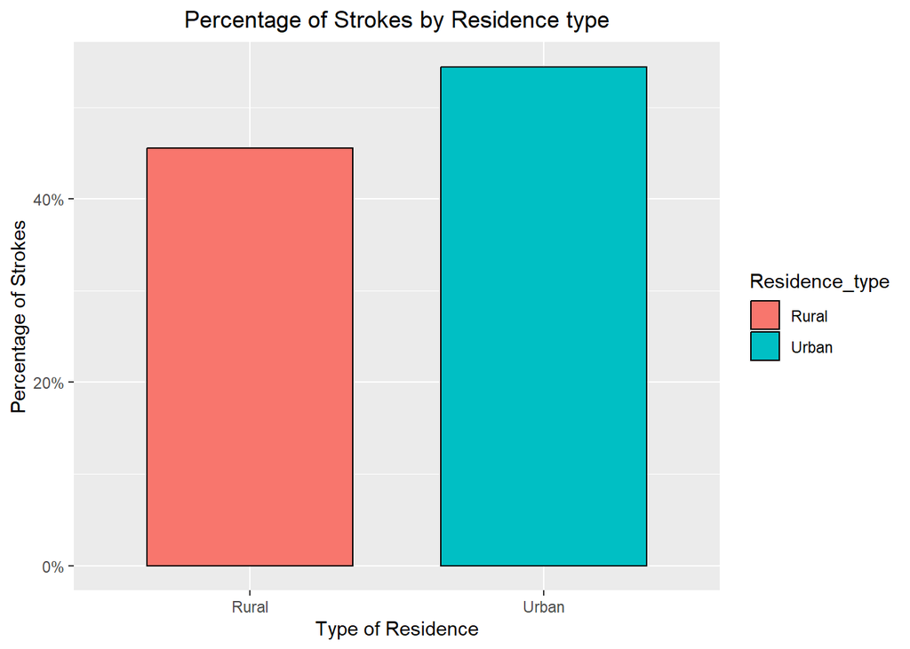

```r
brain_stroke_yes <- brain_stroke_yes %>%
  mutate(Residence_type = case_when(
    Residence_type == 1 ~ "Rural",
    Residence_type == 2 ~ "Urban"
  ))

# Calculate the percentage of brain strokes for each location category
brain_stroke_yes_percentage <- brain_stroke_yes %>%
  group_by(Residence_type) %>%
  summarise(Percentage = (n() / total_cases) * 100)

# Create the bar plot with percentages on the y-axis
ggplot(data = brain_stroke_yes_percentage, aes(x = Residence_type, y = Percentage, fill = Residence_type)) +
  geom_bar(stat = "identity", col = "black", width = 0.7, position = "stack") +
  labs(title = "Percentage of Strokes by Residence type",
       x = "Type of Residence",
       y = "Percentage of Strokes") +
  scale_y_continuous(labels = scales::percent_format(scale = 1)) +  # Format y-axis as percentage
  theme(plot.title = element_text(hjust = 0.5))
```